[figure not shown]

# `cape` Overview

This R package provides an implementation of the ContionAl Prevalence Estimation (or `cape`) apporach proposed in *Accurate Prevalence Estimation for Emerging or Rare Infectious Diseases* by Stéphane Guerrier, Christoph Kuzmics and Maria-Pia Victoria-Feser (submitted manuscript available upon request).

In epidemiological studies, an important quantity that needs to be estimated with great accuracy is the prevalence rate of a disease in order to learn more about central parameters such as case fatality rate and/or to plan and refine decisions about measures with regards to an epidemic or a pandemic. Traditionally, to measure the prevalence, a survey sample (of randomly chosen subjects from the population) is collected and the prevalence is estimated by the sample proportion. This process involves some financial and logistic efforts, which increase with the number of sampled participants, while at the same time, increasing the accuracy of the estimator. Having a sufficiently large sample is especially important when the (true) prevalence is very small, for example at the beginning of a new pandemic such as the one of the COVID-19. In this case, since the beginning of the outbreak, many measurements have been taken on the number of infected people, but only on the sub-population selected under some medical (and logistic) criteria. It is obvious that using these measurements as if they would be like a complete census, would lead to an underestimation of the prevalence.

# Package installation

The `cape` pacakge can be installed from GitHub as follows:

```r
# Install devtools
install.packages("devtools")

# Install the package from GitHub
devtools::install_github("stephaneguerrier/CPreval")
```

# Model

## Mathematical setup

Consider taking a (random) survey sample of $n$ participants in some population in order to estimate the prevalence $\pi$ of, for example, a given infectious disease. The framework also supposes that prior to the collection of the survey sample, measurement have been taken on a sub-population, not necessarily randomly chosen. Conditionally on this information, one can get the prevalence computed as the number of positive cases (in the sub-population) relative to the (whole) population size, i.e. a prevalence parameter $\pi_0$ which is such that $\pi_0 \leq \pi$. While $\pi_0$ is known, it cannot be directly used as a proxy for $\pi$, but the information provided by $\pi_0$, can be used to improve the accuracy of the estimation of $\pi$.

More precisely, for each participant in the survey sample, the following information should be available:

$$\begin{equation}
\begin{aligned}
X_i& :=
\left\{
\begin{array}{ll}
1 & \quad \mbox{if participant $i$ is positive,} \\
0 & \quad \mbox{otherwise;}
\end{array}
\right.\\
V_i& := \left\{
\begin{array}{ll}
1 & \quad \mbox{if participant $i$ is positive and belongs to the sub-population,} \\
0 & \quad \mbox{otherwise.}
\end{array}
\right.
\end{aligned}
\label{eqn:bernoulli-rv}
\end{equation}$$

Note that $\Pr(X_i=1\vert V_i=1) = 1$ and $\Pr(X_i=0\vert V_i=1) = 0$. The objective is to provide an estimator for the unknown prevalence

$$\begin{equation}
\pi := \Pr\left(X_i=1\right).
\label{eqn:true-pi}
\end{equation}$$

However, if we allow for possible misclassification error, the variables in are latent, and what is observed are the following variables

$$\begin{equation}
\begin{aligned}
Y_i& :=
\left\{
\begin{array}{ll}
1 & \quad \mbox{if participant $i$ is tested positive in the survey sample,} \\
0 & \quad \mbox{otherwise;}
\end{array}
\right.\\
W_i& := \left\{
\begin{array}{ll}
1 & \quad \mbox{if participant $i$ is tested positive and belongs to the sub-population,} \\
0 & \quad \mbox{otherwise.}
\end{array}
\right.
\end{aligned}
\label{eqn:bernoulli-rv-obs}
\end{equation}$$

While $Y_i$ is the minimal information collected in the survey sample, $W_i$ is an additional information that could be obtained by asking the participants to provide it. It can be obtained while collecting the information on $Y_i$, or a posteriori using a followup procedure. In that case, it is not necessary to proceed to the followup for all sampled participants, but only for those with $Y_i=1$.

We also suppose that the (medical) testing devices have known sensitivity and specificity, or equivalently, False Positive (FP) rates $\alpha = 1-\mbox{specificity}$ and False Negative (FN) rates $\beta = 1-\mbox{sensitivity}$, that might be different for the two populations. Therefore, we define the following quantities:

$$\begin{equation}
\begin{aligned}
\pi_0 & := \Pr(W_i=1) && \\
\alpha_0& := \Pr(W_i=1\vert V_i=0) & \quad \quad \alpha& := \Pr(Y_i=1\vert X_i=0) \\
\beta_0& := \Pr(W_i=0\vert V_i=1) & \quad \quad \beta& := \Pr(Y_i=0\vert X_i=1).
\end{aligned}
\label{eqn:missclasserrors}
\end{equation}$$

For proper modelling Guerrier, Kuzmics, and Victoria-Feser (2020), we assume that $\alpha+\beta<1$ and $\alpha_0+\beta_0<1$. From the above definitions, we can deduce

$$\begin{equation*}
\pi^*_0=\Pr(V_i=1)=\frac{1}{\Delta_0}(\pi_0-\alpha_0)
\end{equation*}$$

with $\Delta_0=1-(\alpha_0+\beta_0)$. In the figure below the probability tree associated to the variables presented previously:

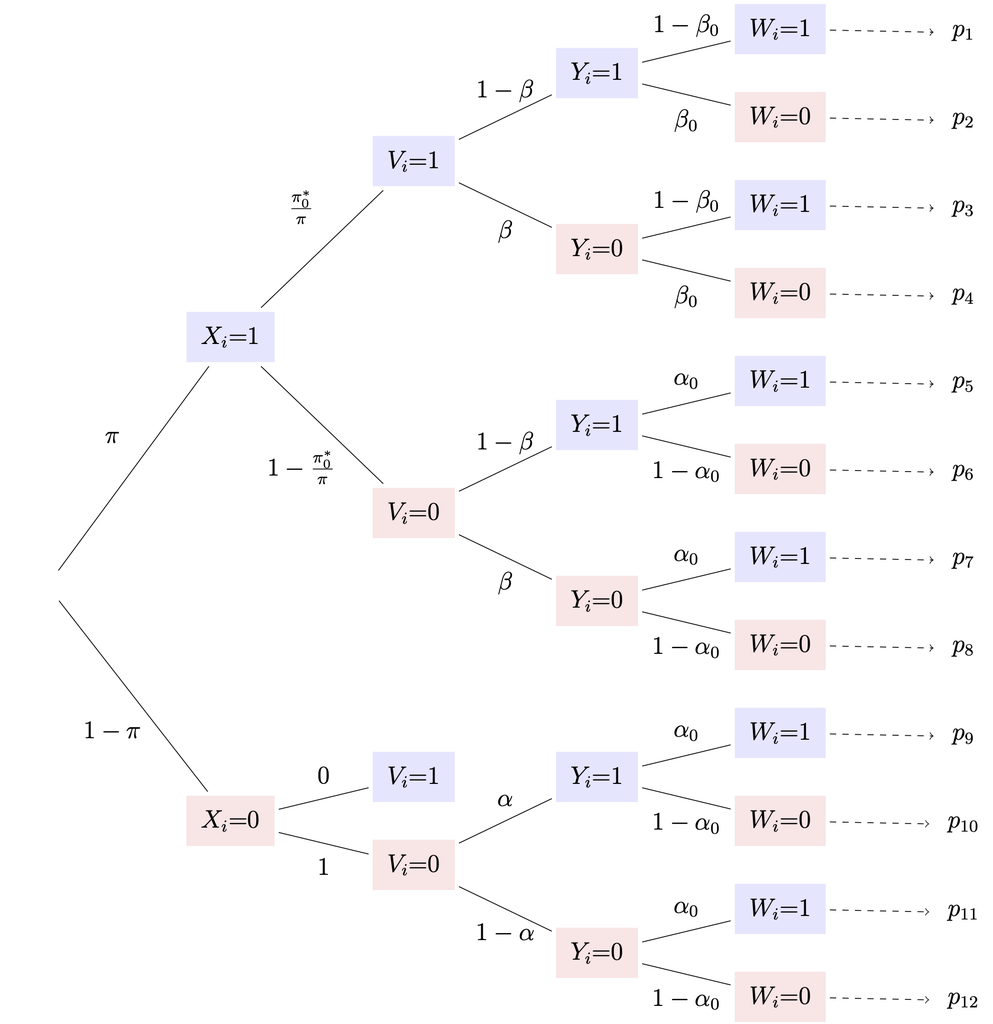

From these variables we deduce the following random variables that are necessary for estimation and inference:

$$\begin{eqnarray}
R_1:=\sum_{i=1}^nY_iW_i \;\;\; \mbox{and} \;\;\;
R_3:= \sum_{i=1}^nY_i(1-W_i)
\label{eqn:R-R4}
\end{eqnarray}$$

with:

- $R_1$: the number of participants in the survey sample that were tested positive with both (medical) testing devices (and are, thus, members of the sub-population);
- $R_3$ is the number of participants in the survey sample that are tested positive only with the second testing device.

If easily available, on can add the following information, that might increase estimation and inference accuracy for survey sample sizes smaller than $n=1,500$:

$$\begin{equation*}
R_2:=\sum_{i=1}^n(1-Y_i)W_i
\end{equation*}$$

so that $R_0:= \sum_{i=1}^nW_i=R_1+R_2$, with

- $R_0$: the number of participants in the survey sample that were tested positive in the sub-population;
- $R_2$: the number of participants in the survey sample that are tested positive only with the first testing device (and are, thus, members of the sub-population).

The respective distributions of $R_1,R_2,R_3$ are binomial distributions with success probabilities given below in the next section.

## Simulating data

Data can be simulated using the function `sim_Rs()` as follows:

```r
# Measurement error
alpha = alpha0 = 0.01
beta = beta0 = 0.02

# Simulation "seed"
seed = 18

# True prevalence
theta = 4/100

# Prevalence in sub-population
pi0 = 2/100

# Sample size
n = 1500

# Simulation data
R = sim_Rs(theta = theta, pi0 = pi0, n = n, alpha0 = alpha0,
           alpha = alpha, beta0 = beta0, beta = beta, seed = seed)

# Print results
R
```

```
#> Data: R = 71, R0 = 36, n = 1500
#>       R1 = 19, R2 = 17, R3 = 52, R4 = 1412
#>
#> Assumed measurement error: alpha0 = 1%, alpha = 1%,
#>                            beta0  = 2%, beta  = 2%
```

# Estimators

The success probabilities associated to $R_j,j=1,2,3$ are functions of the (true) prevalence $\pi$, and are given by

$$\begin{eqnarray}
\begin{aligned}
\tau_1(\pi) &:= \Pr(W_i=1, Y_i=1) =\pi\Delta\alpha_0+\pi_0^*\Delta_0(1-\beta)+\alpha\alpha_0 \\
\tau_2(\pi) &:= \Pr(W_i=1,Y_i=0) = -\pi\Delta\alpha_0+\pi_0^*\Delta_0\beta+(1-\alpha)\alpha_0 \\
\tau_3(\pi) &:= \Pr(W_i=0,Y_i=1) = \pi\Delta(1-\alpha_0)-\pi_0^*\Delta_0(1-\beta)+\alpha(1-\alpha_0) \\
\tau_4(\pi) &:= \Pr(W_i=0,Y_i=0) = -\pi\Delta(1-\alpha_0)-\pi_0^*\Delta_0\beta+(1-\alpha)(1-\alpha_0),
\end{aligned}
\label{eqn:tau-pi}
\end{eqnarray}$$

where $\Delta :=1-(\alpha+\beta)$. A likelihood function can be built based on the multinomial distribution (with categories $R_1,R_2,R_3,R_4$, with $R_4=1-R_1-R_2-R_3$) to obtain the Maximum Likelihood Estimator (MLE) for $\pi$ Guerrier, Kuzmics, and Victoria-Feser (2020). The MLE has a closed form expressions if $\alpha_0=0$. If the information provided by $R_2$ is not available, the likelihood function is marginalized out on $R_2$ and one can still obtain an MLE for $\pi$. Alternatively, the package also contains a Method of Moments Estimator (MME) based on $R_3$ (with expectation $\tau_3(\pi)$), which is closed form for any $\alpha_0,\alpha,\beta_0,\beta$.

The confidence intervals for the MLE and the marginal MLE can be computed using asymptotic theory. They provide good coverage, with small interval length for survey sample sizes from $n=1,000$ Guerrier, Kuzmics, and Victoria-Feser (2020). For the MME, since its finite sample distribution is known through $R_3\sim\mathcal{B}(n,\tau_3(\pi))$, exact confidence bounds can be computed using, for example, the (fiducial) Clopper–Pearson (CP) approach method, see Clopper and Pearson (1934), Fisher (1935) and Brown, Cai, and DasGupta (2001). In the package are implemented, the CP method based on $R_3$, and the asymptotic theory method for the MLE (with $R_2$ known or not). An extensive simulation study is provided in Guerrier, Kuzmics, and Victoria-Feser (2020) that compares coverage probabilities with the different approaches.

To obtain these estimators, one can use the functions `mle()`, `marginal_mle()` and `moment_estimator()`. Indeed, the MLE can be estimate as follows on the data previously simulated:

```r
fit_mle = mle(R1 = R$R1, R2 = R$R2, R3 = R$R3, R4 = R$R4, n = R$n, pi0 = R$pi0,
              alpha0 = R$alpha0, alpha = R$alpha,
              beta0 = R$beta0, beta = R$beta)
fit_mle
```

```
#> Method: MLE
#>
#> Estimated proportion: 3.6168%
#> Standard error      : 0.4926%
#>
#> Confidence intervals at the 95% level:
#> Asymptotic Approach: 2.6512% - 4.5823%
#>
#> Assumed measurement error: alpha0 = 1%, alpha = 1%,
#>                            beta0  = 2%, beta  = 2%
```

Note that the MLE is based on $R_1$, $R_2$, $R_3$ and $R_4$ while the marginal MLE simply considered the information in $R_1$ and $R_3$. This estimator can be obtained as follows:

```r
fit_mmle = marginal_mle(R1 = R$R1, R3 = R$R3, n = R$n, pi0 = R$pi0,
                        alpha0 = R$alpha0, alpha = R$alpha,
                        beta0 = R$beta0, beta = R$beta)
fit_mmle
```

```
#> Method: Marginal MLE
#>
#> Estimated proportion: 3.6160%
#> Standard error      : 0.4927%
#>
#> Confidence intervals at the 95% level:
#> Asymptotic Approach: 2.6504% - 4.5816%
#>
#> Assumed measurement error: alpha0 = 1%, alpha = 1%,
#>                            beta0  = 2%, beta  = 2%
```

Moreover, the moment estimator, which is simply based on $R_3$, can be computed as follows:

```r
fit_mme = moment_estimator(R3 = R$R3, n = R$n, pi0 = R$pi0,
                           alpha0 = R$alpha0, alpha = R$alpha,
                           beta0 = R$beta0, beta = R$beta)
fit_mme
```

```
#> Method: Moment Estimator
#>
#> Estimated proportion: 3.5996%
#> Standard error      : 0.4919%
#>
#> Confidence intervals at the 95% level:
#> Asymptotic Approach: 2.6355% - 4.5636%
#> Clopper-Pearson    : 2.6968% - 4.6979%
#>
#> Assumed measurement error: alpha0 = 1%, alpha = 1%,
#>                            beta0  = 2%, beta  = 2%
```

It can be observed that this estimator provides asymtoptic and CP confidence intervals. Finally for comparison purpuses, we implemented the standard sample average estimator which can be obtained as follows:

```r
fit_mean = survey_sample(R = R$R, n = R$n, alpha = R$alpha, beta = R$beta)
fit_mean
```

```
#> Method: Survey sample
#>
#> Estimated proportion: 3.8488%
#> Standard error      : 0.5652%
#>
#> Confidence intervals at the 95% level:
#> Asymptotic Approach: 2.7409% - 4.9567%
#> Clopper-Pearson    : 2.7990% - 5.0858%
#>
#> Assumed measurement error: alpha = 1%, beta = 2%
```

# License

The license this source code is released under is the GNU AFFERO GENERAL PUBLIC LICENSE (AGPL) v3.0. Please see the LICENSE file for full text. Otherwise, please consult TLDR Legal or [GNU](https://www.gnu.org/licenses/agpl-3.0.en.html) which will provide a synopsis of the restrictions placed upon the code.

# References

Brown, L. D., T. Cai, and A. DasGupta. 2001. “Interval Estimation for a Binomial Proportion.” *Statistical Science* 16: 101–33.

Clopper, C. J., and E. S. Pearson. 1934. “The Use of Confidence or Fiducial Limits Illustrated in the Case of the Binomial.” *Biometrika* 26: 404–13.

Fisher, R. A. 1935. “The Fiducial Argument in Statistical Inference.” *Annals of Eugenics* 6: 391–98.

Guerrier, S, C Kuzmics, and M.-P. Victoria-Feser. 2020. “Accurate Prevalence Estimation for Emerging or Rare Infectious Diseases.”